# Spectral analysis and observation processing example

## 5.3. Some chart alternatives

```r
directory <- "./output/alternatives/"
dir.create(directory)
```

Some possible alternatives:

- If the status are not relevant for the desired analysis, some parameters allow to ignore them on charts.
- Because vertices of the spectrosome are positioned partially randomly, it may be necessary to redo a graph to get better readability. A parameter allows to plot as many spectrosome as you want.
- Another parameter allows to reduce the number of links displayed on a spectrosome according to their weight.

```r
# Plot 3 spectrosomes coloring the vertices with the categories
spectrosome_1 <- spectrosome_chart(sa_object, sa_object["patterns"],
                                   vertex_col = "categories",
                                   nb_graphs = 3,
                                   path = directory,
                                   name = "spectrosome_of_patterns-no_status.png")
```

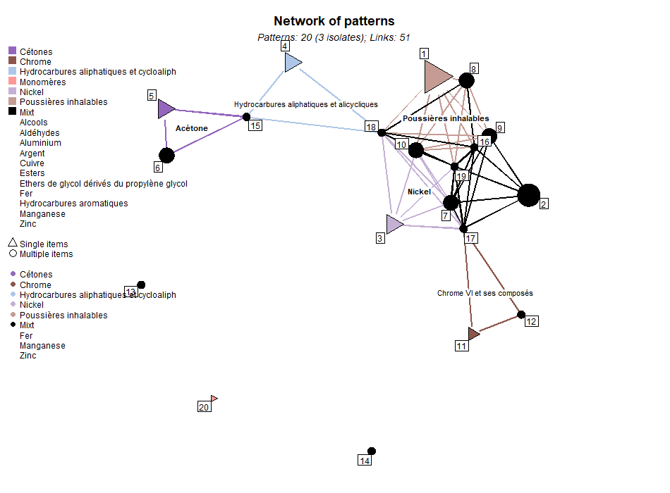

Fig. 16.a: Spectrosome in which vertices are colored according to the category associated with the items, example 1.

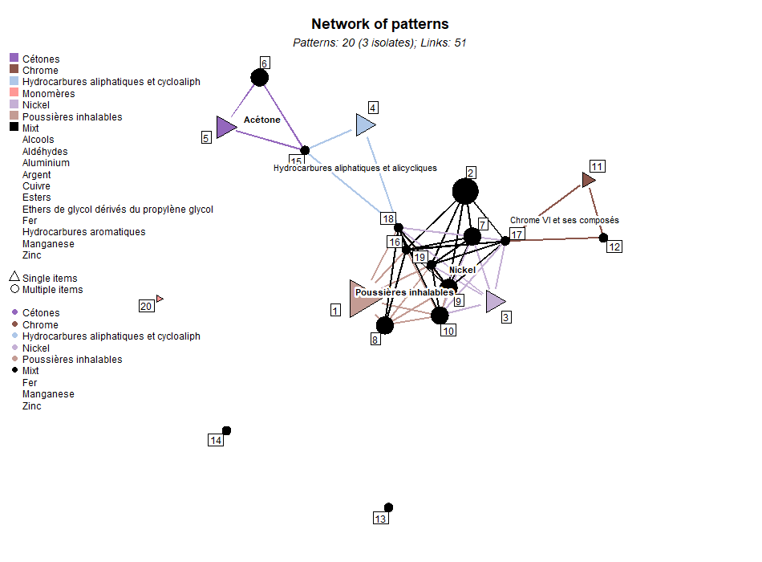

Fig. 16.b: Spectrosome in which vertices are colored according to the category associated with the items, example 2.

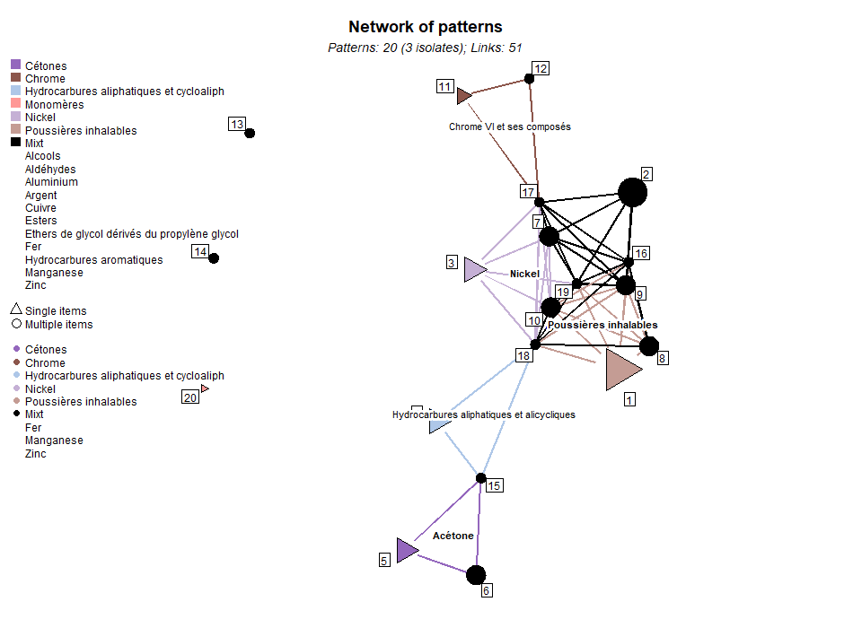

Fig. 16.c: Spectrosome in which vertices are colored according to the category associated with the items, example 3.

One can choose one of the three spectrosomes plotted and reuse it with the parameter `coord`. For instance, one can plot again the third spectrosome with another constraint on links:

```r
# Spectrosomes with several values for the parameter defining the minimum weight of a link to be plotted.
for (min_weight in seq(2, 5)) {
  spectrosome_w <- spectrosome_chart(sa_object, sa_object["patterns"],
                                     min_link_weight = min_weight,
                                     vertex_col = "categories",
                                     path = directory,
                                     name = paste0("spectrosome_of_patterns-weight", min_weight),
                                     coord = spectrosome_1$coords[[3]])
}
```

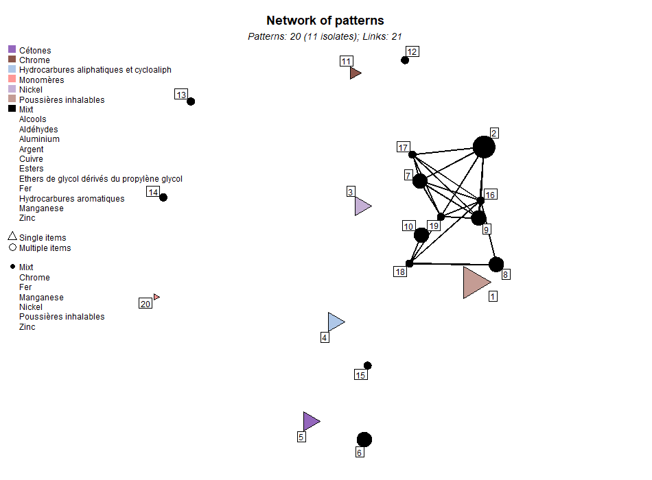

Fig. 17.a: Spectrosome with the constraint of a minimum link weight of 2.

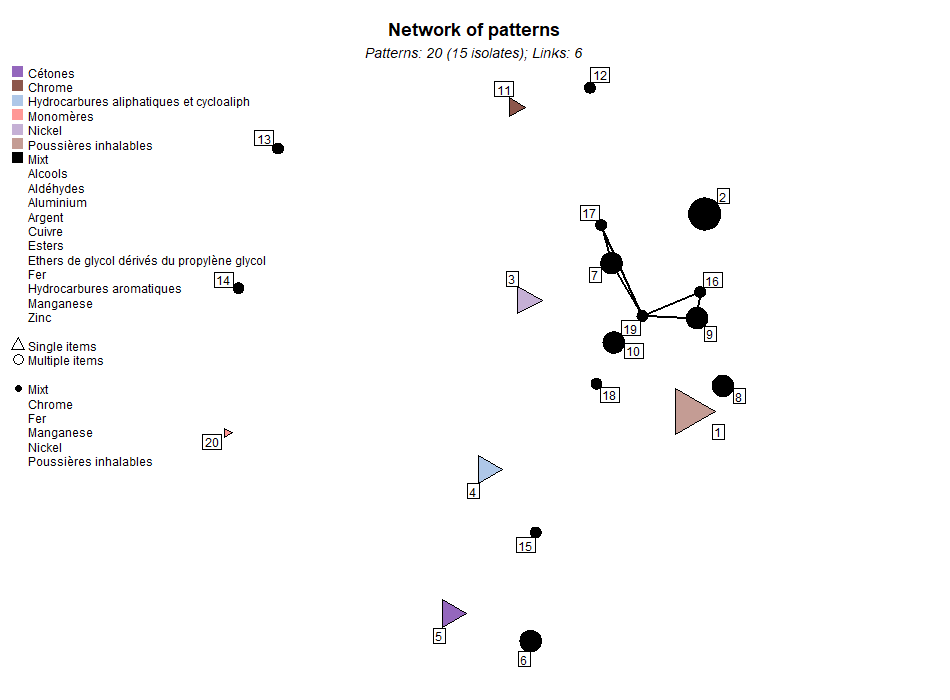

Fig. 17.b: Spectrosome with the constraint of a minimum link weight of 3.

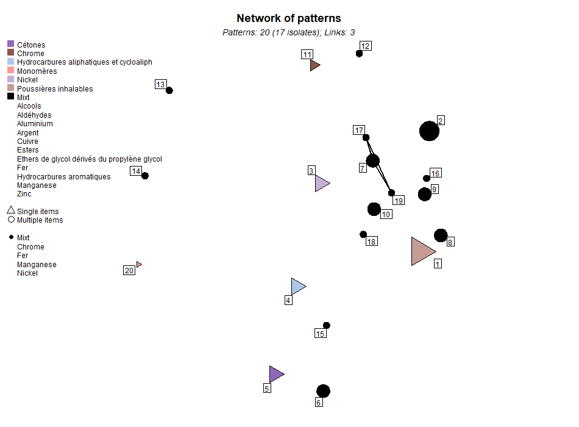

Fig. 17.c: Spectrosome with the constraint of a minimum link weight of 4.

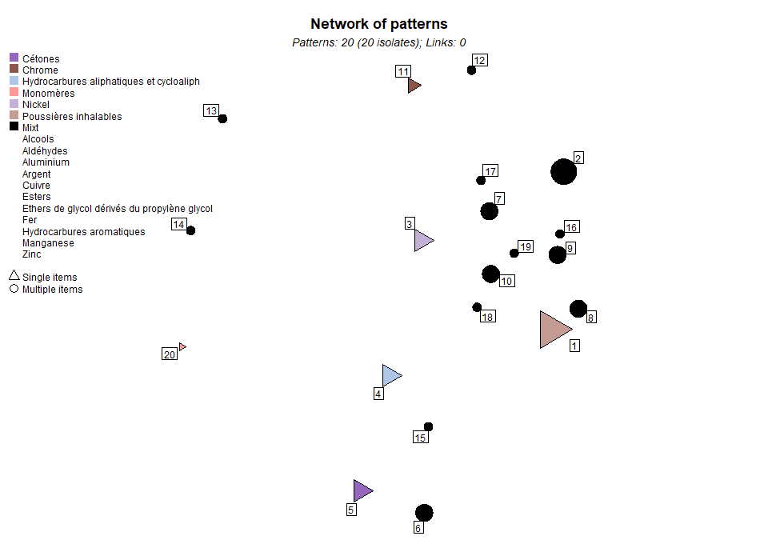

Fig. 17.d: Spectrosome with the constraint of a minimum link weight of 5.

## 5.4. Working with association rules

### 5.4.1. Extracting association rules

There are 4 ways to look for association rules (i.e. implication between two itemsets):

1. Looking for all rules within the observations.
2. Looking for rules whose union of the antecedent and the consequent form an entire pattern.
3. Looking for rules whose union of the antecedent and the consequent form an entire itemset among those defined in argument.
4. Looking for rules related to items specified in arguments as antecedent or consequent.

**Note that only rules with one item in the consequent are created.**

```r
# All rules (with a support threshold of 0.1)
rules_1 <- extract_rules(sa_object, from = "observations")
rules_1
```

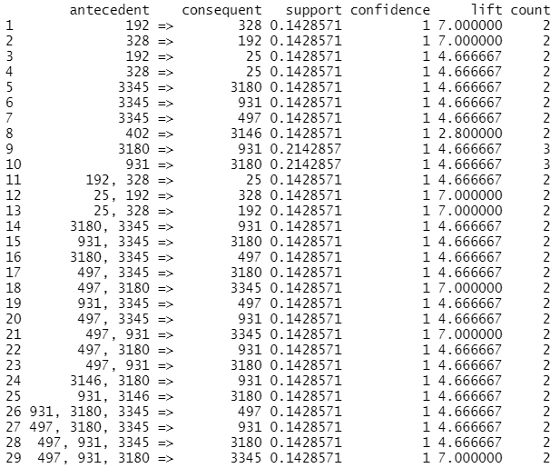

```r
# Rules forming the patterns (without support threshold)
rules_2 <- extract_rules(sa_object, from = "patterns")
rules_2
```

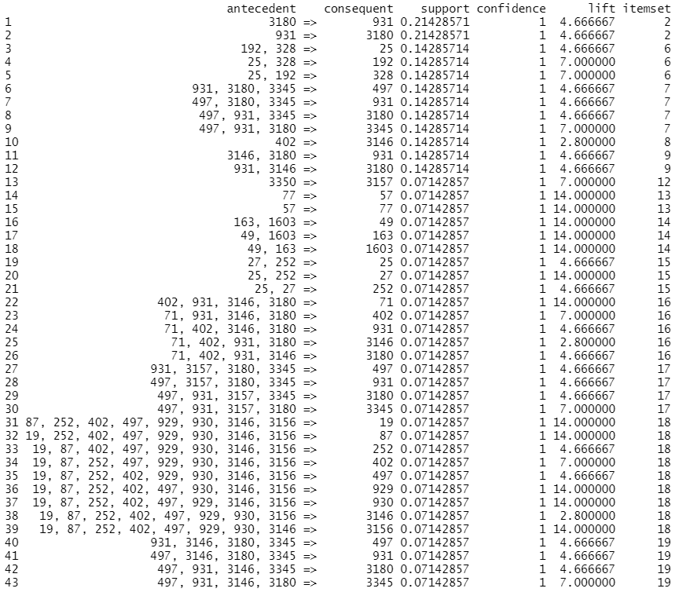

```r
# Rules forming 2 specific itemsets
rules_3 <- extract_rules(sa_object, from = list(c("931", "3180"),
                                                c("25", "192", "328")))
rules_3
```

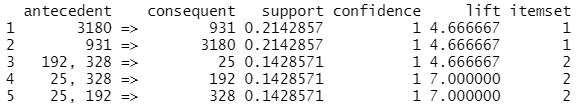

```r
# Rules having the substance "328" as consequent and only one substance as antecedent
rules_4a <- extract_rules(sa_object, from = "observations",
                          parameter = list(supp = 0.001, conf = 0.5, maxlen = 2),
                          appearance = list(rhs = "328"))
rules_4a
```

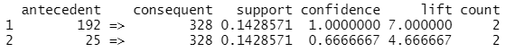

The confidence of 1 means that the substance *328* is found each time the substance *192* is found. In other words, the presence of the substance *192* implies that of the substance *328*.

```r
# Rules having the substance "497" as antecedent
rules_4b <- extract_rules(sa_object, from = "observations",
                          parameter = list(supp = 0.001, conf = 0.5, maxlen = 2),
                          appearance = list(lhs = "497"))
rules_4b
```

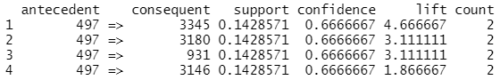

```r
# Rules in which the substance "328" is the antecedent and the substance "3180" is the consequent (with confidence threshold of 0)
rules_4c <- extract_rules(sa_object, from = "observations",
                          parameter = list(supp = 0.001, conf = 0, minlen = 2, maxlen = 2),
                          appearance = list(lhs = "328", rhs = "3180"))
rules_4c
```

[output not shown]

The `NULL` result means that no association rule exists between the substances *328* as antecedent and *3180* as consequent. In other words, the presence of the substance *328* implies the absence of the substance *3180* and the presence of the *3180* implies the absence of the *328*.

Furthermore, the confidence of a rule can be used to infer the confidence of the implication of the absence of the consequent, using the complement to 1:

```r
cat("Confidence of the rule 497 => 3345:    ", rules_4b[1, "confidence"])
```

```
Confidence of the rule 497 => 3345:     0.6666667
```

```r
cat("\nConfidence of the rule 497 => not 3345:", 1 - rules_4b[1, "confidence"])
```

```
Confidence of the rule 497 => not 3345: 0.3333333
```

### 5.4.2. Visualizing and saving association rules

Rules are saved in the same way as for nodes or patterns.

```r
directory <- "./output/rules/"
dir.create(directory)

save_characteristics(sa_object, rules_1,
                     file = paste0(directory, "rules.csv"), row.names = FALSE)
```

Association rules of length 2 can be plotted using the function `rules_chart`. If no rule is given as argument, all rules of length 2 are automatically extracted before being plotted:

```r
rc <- rules_chart(SA_instance, items = SA_instance["items"], category = "family")
rc$rules
```

|  | antecedent |  | consequent | support | confidence | lift | count |
| --- | --- | --- | --- | --- | --- | --- | --- |
| 1 | 3350 | => | 3157 | 0.07142857 | 1.0000000 | 7.0000000 | 1 |
| 2 | 3157 | => | 3350 | 0.07142857 | 0.5000000 | 7.0000000 | 1 |
| 3 | 57 | => | 77 | 0.07142857 | 1.0000000 | 14.0000000 | 1 |
| 4 | 77 | => | 57 | 0.07142857 | 1.0000000 | 14.0000000 | 1 |
| 5 | 27 | => | 25 | 0.07142857 | 1.0000000 | 4.6666667 | 1 |
| 6 | 25 | => | 27 | 0.07142857 | 0.3333333 | 4.6666667 | 1 |
| 7 | 27 | => | 252 | 0.07142857 | 1.0000000 | 4.6666667 | 1 |
| 8 | 252 | => | 27 | 0.07142857 | 0.3333333 | 4.6666667 | 1 |
| 9 | 49 | => | 163 | 0.07142857 | 1.0000000 | 14.0000000 | 1 |
| 10 | 163 | => | 49 | 0.07142857 | 1.0000000 | 14.0000000 | 1 |

[output cut: 122 more lines]

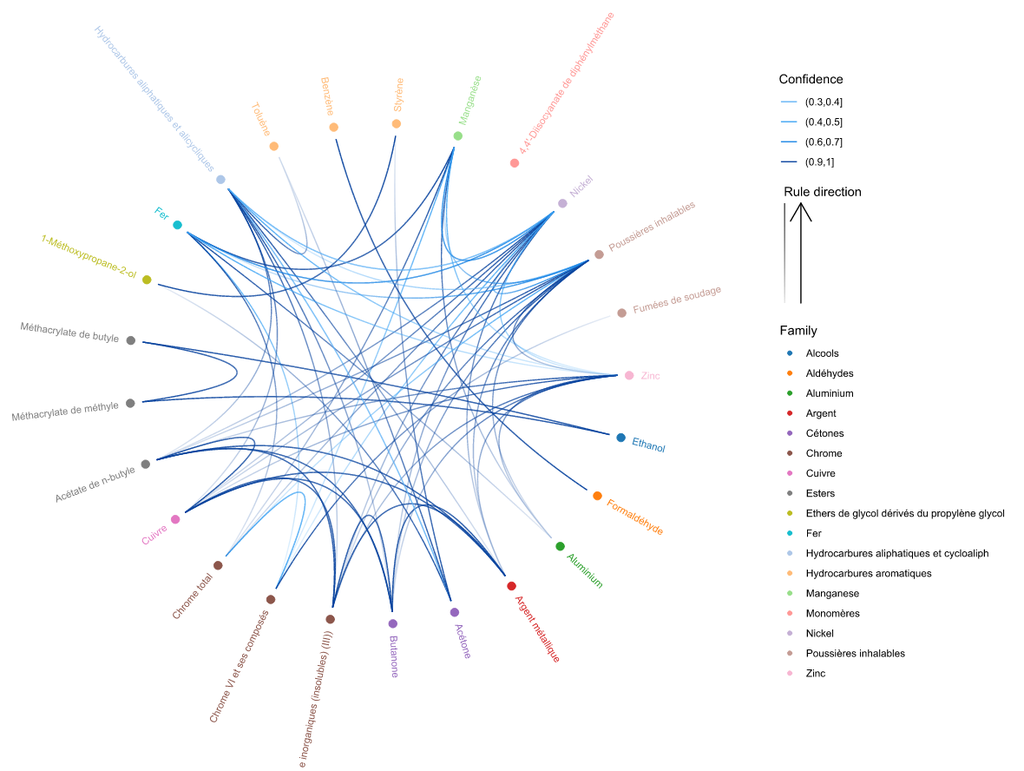

```r
plot(rc$graph)
```

### 5.4.3. Association rules as rules class object from the package arules

The argument `arules` of the function `extract_rules` allows to get rules as an object of class `rules` from the package `arules`. Such rules can be plotted using functions of the package `arulesViz` (see [arulesViz documentation](https://cran.csiro.au/web/packages/arulesViz/vignettes/arulesViz.pdf) for more visualizations).

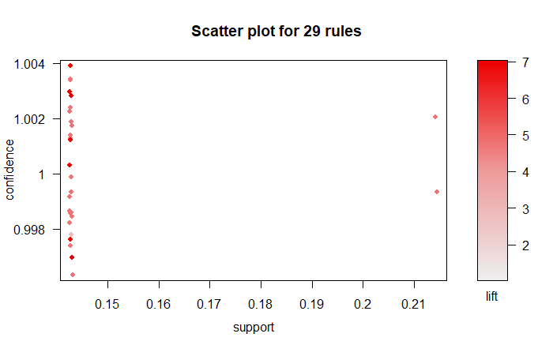

```r
library(arulesViz)
a_rules <- extract_rules(sa_object, from = "observations", arules = TRUE)
plot(a_rules)
```

## 5.5. Alternative initialization and patterns

If some of the features are not interesting for a specific analysis and the amount of data implies a long object creation time, we may want to save time by not initializing some attributes.

For example, if spectrosomes and clusters of nodes do not matter for an analysis, we can manually initialize all attributes of a `SpectralAnalyzer` object except those concerning the links between the nodes:

```r
alt_sa_object <- spectral.analyzer(observations, items, init = FALSE)
init(alt_sa_object, "nodes")
```

```
*** Step N.1/2: Enumeration of the observations per year... [00s]
*** Step N.2/2: Enumeration of the nodes and calculation of the number of occurrences... [00s]
```

```r
init(alt_sa_object, "patterns")
```

```
*** Step P.1/4: Mining for itemsets...
```

```
You chose a very low absolute support count of 1. You might run out of memory! Increase minimum support.
```

```
[00s]
*** Step P.2/4: Linking nodes to patterns... [00s]
*** Step P.3/4: Characterization of patterns per year... [00s]
*** Step P.4/4: Computation of pattern characteristics... [00s]
```

```r
# init(alt_sa_object, "node_links")
init(alt_sa_object, "pattern_links")
```

```
*** Step PL.1/2: Counting links between patterns... [00s]
*** Step PL.2/2: Elaboration of links between patterns... [00s]
```

```r
is_init(alt_sa_object)
```

```
    n    nl     p    pl
 TRUE FALSE  TRUE  TRUE
```

In this way the patterns can be obtained as `itemsets`, an object of a class from the package `arules`. See [arules documentation](https://cran.r-project.org/web/packages/arules/vignettes/arules.pdf) to know how to work with this class.

```r
itemsets <- init(alt_sa_object, "patterns", verbose = FALSE)
```

```
You chose a very low absolute support count of 1. You might run out of memory! Increase minimum support.
```

```r
library(arules)
inspect(itemsets)
```

|  | items | support | count |
| --- | --- | --- | --- |
| [1] | {3157,3350} | 0.07142857 | 1 |
| [2] | {57,77} | 0.07142857 | 1 |
| [3] | {49,163,1603} | 0.07142857 | 1 |
| [4] | {25,27,252} | 0.07142857 | 1 |
| [5] | {71,402,931,3146,3180} | 0.07142857 | 1 |
| [6] | {25,192,328} | 0.14285714 | 2 |
| [7] | {497,931,3157,3180,3345} | 0.07142857 | 1 |
| [8] | {19,87,252,402,497,929,930,3146,3156} | 0.07142857 | 1 |
| [9] | {497,931,3146,3180,3345} | 0.07142857 | 1 |
| [10] | {497,931,3180,3345} | 0.14285714 | 2 |

[output cut: 10 more lines]

# List of datasets, functions, classes and methods

The package help page: oedb.analysis.tools

## Datasets

Datasets used as examples:

- oedb_sample
- substances_information
- OS_instance
- SA_instance

## About observations

The class: ObservationSet

Making *ObservationSet* objects:

- observation.set
- make_observations
- make_OE_observations
- [ and [<-

Search in observations:

- get_all_items
- get_itemsets
- get_items_from_info
- get_info_from_items

Search for observations:

- get_complex_obs
- get_simple_obs
- get_obs_from_items
- get_obs_from_info

Computations on observations:

- complexity_ratio
- complexity_index
- co_occurrence_matrix

Making charts about observations:

- co_occurrence_chart

## About spectral analysis

The class: SpectralAnalyzer

Making *SpectralAnalyzer* objects:

- spectral.analyzer
- init and is_init
- reset
- [ and [<-

Making charts:

- spectrosome_chart
- cluster_chart
- spectrum_chart
- itemset_chart
- category_tree_chart
- co_occurrence_chart

Search for nodes or patterns:

- get_nodes
- get_patterns
- get_complexes
- get_isolates
- get_non_isolates

Search for links between nodes or between patterns:

- get_links

Computations on spectrosomes:

- degree
- network_density

Computations on nodes and patterns:

- weight_by_node_complexity
- define_dynamic_status

Saving nodes or patterns:

- save_characteristics

## About association rules and sets

Extracting, visualizing and saving rules:

- extract_rules
- rules_chart
- save_characteristics

Switching between mathematical notation and vector notation for sets:

- vector_notation
- set_notation

## About the maximum cumulative ratio approach

Computation of the main indicators:

- hazard_quotient
- hazard_index
- maximum_hazard_quotient
- maximum_cumulative_ratio
- missed_toxicity

Computation of additional indicators:

- reciprocal_of_mcr
- top_hazard_quotient
- classify_mixture

Summarising indicators:

- mcr_summary
- mcr_chart
- thq_pairs
- thq_by_group

Application of the approach according to a classification

- mcr_approach_by_class
- mcr_summary_by_class
- mcr_chart_by_class
- thq_pairs_by_class
- thq_by_group_by_class

## About lists

Computations on lists:

- intersect_on_list
- union_on_list
- table_on_list

Transformation of lists and transformation into lists:

- invert_list
- coerce_list
- coerce_to_list

Search in lists:

- nth_values